```python
!pip install pyarrow==2.0.0
!pip install spacy==2.3.5
!pip install langdetect==1.0.8
!pip install fasttext==0.9.2
!pip install umap==0.1.1
!pip install umap-learn==0.4.6
!pip install hdbscan==0.8.26

# get pretrained fasttext models for language detection
!wget -O /tmp/lid.176.bin https://dl.fbaipublicfiles.com/fasttext/supervised-models/lid.176.bin

# download spacy pretrained small English model
!python3 -m spacy download en_core_web_sm
```

[output not shown]

# Which Product should I add??

In order to help the Vendor in the process of adding competetive products, we can propose 2 simultaneous solutions:

#### 1) Suggesting the most successful products from other similar vendors

In this scenario we will need to find "similar" products based on product name and description. We can imagine an application, where once the vendor decide the location it can serve, we propose automatically the list of top 10 successful products from other vendors in that location.

#### 2) Demand Prediction

We can assist the vendor in the processing of adding new items, by predicting the amount of orders to expect over the next 30 days. We can imagine a ML model updating the demand prediction in real-time while the vendor documents the new products in the app :) We can gamify the process and let the vendor maximize its expected score by improving the product name or description for example.

# What will this notebook cover?

- Data loading and exploratory data analysis
- Cleaning of data: removing non-english products, clean text (removing stopwords/digits, lemmatization, ...)
- Clustering of similar products
- Proposing top 10 successful products from **similar vendors**

### Load Data

```python
import pandas as pd
import numpy as np
import seaborn as sns
import matplotlib.pyplot as plt
from collections import Counter

import fasttext
import nltk
from nltk.corpus import stopwords
from nltk.tokenize import word_tokenize
from nltk.stem import WordNetLemmatizer
import en_core_web_sm
import umap.umap_ as umap
import hdbscan
import matplotlib.pyplot as plt
from mpl_toolkits.mplot3d import Axes3D
from sklearn.ensemble import IsolationForest

from tqdm import tqdm

nltk.download('stopwords')
nltk.download('wordnet')

tqdm.pandas()

%matplotlib inline
```

```python
FASTTEXT_PATH_MODEL = '/tmp/lid.176.bin'
```

```python
df = pd.read_parquet("Documents/delivery_hero/products.parquet.gz")
nrows = df.shape[0]
```

# Exploratory Data Analysis`

### Basic checkups

Are there any duplicates? Any NaN values? what's the relationship between product, vendor and location in the table?

```python
# Any NaN values?
(df.isnull().sum() / nrows) * 100
```

```
product_id              0.00000
vendor_id               0.00000
vendor_geohash          0.00000
product_name            0.00000
product_description    48.06854
order_count             0.00000
dtype: float64
```

##### Nearly half of product description is empty

```
Is column product_id unique: True
Is column vendor_id unique: False
Is column vendor_geohash unique: False
```

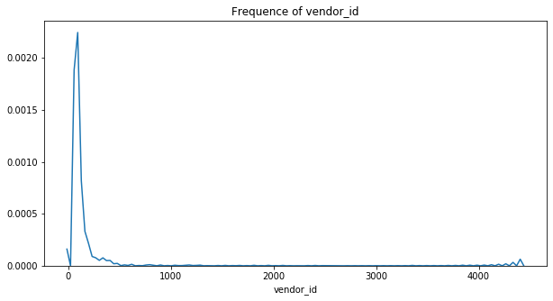

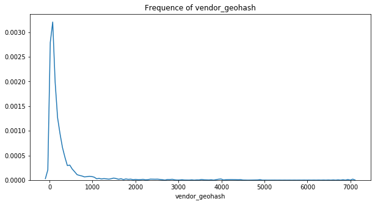

```python
for col in ["product_id", "vendor_id", "vendor_geohash"]:
    # check if column is unique
    is_col_unique = df[col].is_unique
    print(f"Is column {col} unique: {is_col_unique}")
    if not is_col_unique:
        plt.figure(figsize=(10, 5))
        sns.distplot(df.groupby(col)[col].count(), hist=False)
        plt.title(f"Frequence of {col}")
```

### How many unique products do vendors propose? 🤔

Based on the graph below, something seems fishy ... How likely it is that a given vendor proposes around 4500 different products alone, with different product names. It might be outliers or other data issues.

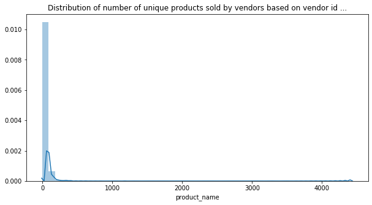

```python
cnt = df.groupby(["vendor_id"]).product_name.nunique().sort_values(ascending=False)

plt.figure(figsize=(10, 5))
sns.distplot(cnt)
plt.title("Distribution of number of unique products sold by vendors based on vendor id ...")
```

### (Follow-up Question to observation above) Do we have duplicated rows? ... Yes we do

As the product Id is unique, we can try to assess this combining different unique identifiers. If we take the strictest case with ["vendor_id", "vendor_geohash", "product_name", "product_description", "order_count"] as identifiers we have around 7% of our rows that are duplicates ... that is likely a data issue.

For the less strict cases (e.g. taking ["vendor_id", "vendor_geohash", "product_name", "product_description"]), why does the `order_count` differ?

```python
identifiers = ["vendor_id", "vendor_geohash", "product_name"]
d_pn = df.duplicated(identifiers).sum()
print(f"{np.round((d_pn / nrows) * 100, 2)}% of raw are duplicates using {identifiers}")
```

```
20.13% of raw are duplicates using ['vendor_id', 'vendor_geohash', 'product_name']
```

```python
identifiers = ["vendor_id", "vendor_geohash", "product_name", "product_description"]
d_pn = df.duplicated(identifiers).sum()
print(f"{np.round((d_pn / nrows) * 100, 2)}% of raw are duplicates using {identifiers}")
```

```
19.76% of raw are duplicates using ['vendor_id', 'vendor_geohash', 'product_name', 'product_description']
```

```python
identifiers = ["vendor_id", "vendor_geohash", "product_name", "product_description", "order_count"]
d_pn = df.duplicated(identifiers).sum()
print(f"{np.round((d_pn / nrows) * 100, 2)}% of raw are duplicates using {identifiers}")
```

```
7.15% of raw are duplicates using ['vendor_id', 'vendor_geohash', 'product_name', 'product_description', 'order_count']
```

```python
identifiers = ["vendor_id", "vendor_geohash", "product_name", "order_count"]
d_pn = df.duplicated(identifiers).sum()
print(f"{np.round((d_pn / nrows) * 100, 2)}% of raw are duplicates using {identifiers}")
```

```
7.22% of raw are duplicates using ['vendor_id', 'vendor_geohash', 'product_name', 'order_count']
```

#### !! DROP the duplicates, and simply take the highest order_count !!

```python
df = df.sort_values(["vendor_id", "order_count"], ascending=False).drop_duplicates(
    ["vendor_id", "vendor_geohash", "product_name"]
)
```

### Even after the drop we still have vendors selling suspiciously too many unique products ... and other selling only 1

#### have to remove them, using a rule or model: here IsolationForest

### !! DROP the outliers !!

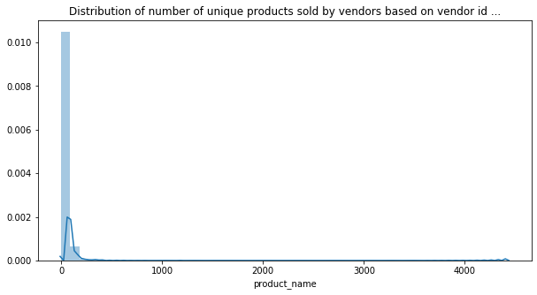

```python
cnt = df.groupby(["vendor_id", "vendor_geohash"]).product_name.nunique().sort_values(ascending=False)

plt.figure(figsize=(10, 5))
sns.distplot(cnt)
plt.title("Distribution of number of unique products sold by vendors based on vendor id ...")
```

```python
cnt_u_p = pd.DataFrame(cnt.reset_index()).rename(columns={"product_name": "count_unique_products"})
isf = IsolationForest(n_estimators=300)
isf.fit(cnt_u_p["count_unique_products"].values.reshape(-1, 1))
cnt_u_p["is_outlier"] = isf.predict(cnt_u_p["count_unique_products"].values.reshape(-1, 1))
```

```python
# These vendors below are outliers
cnt_u_p.loc[cnt_u_p.is_outlier == -1]
```

|  | vendor_id | vendor_geohash | count_unique_products | is_outlier |
| --- | --- | --- | --- | --- |
| 0 | 61 | w21z675 | 4425 | -1 |
| 1 | 81 | w21zsbb | 4375 | -1 |
| 2 | 17 | w23b5j9 | 4359 | -1 |
| 3 | 69 | w21zv1d | 4227 | -1 |
| 4 | 106 | w21z6cf | 4219 | -1 |
| ... | ... | ... | ... | ... |
| 1968 | 2511 | w21zv97 | 62 | -1 |
| 1969 | 4480 | w21z6vj | 62 | -1 |
| 1970 | 3924 | w21zg82 | 62 | -1 |
| 1971 | 1503 | w21zv3y | 62 | -1 |
| 1972 | 1644 | w21zetv | 62 | -1 |

1973 rows × 4 columns

```python
# DELETE THESE OUTLIERS
df = df.merge(cnt_u_p)
df = df.loc[df.is_outlier != -1]
```

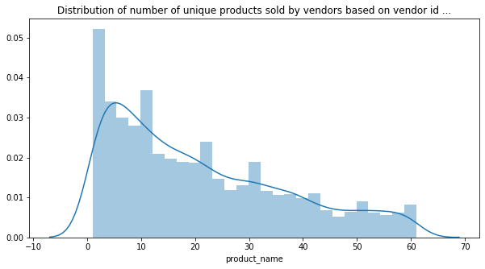

```python
cnt_clean = df.groupby(["vendor_id", "vendor_geohash"]).product_name.nunique().sort_values(ascending=False)

plt.figure(figsize=(10, 5))
sns.distplot(cnt_clean)
plt.title("Distribution of number of unique products sold by vendors based on vendor id ...")
```

## Now it looks logical and Clean 😉

## Detect language based on combination of Product Name and Product Description

Combining the title and description when running the language detector would help reduce false classifications. As some of the product names are too short and can easily lead to false language classification.

#### Which librarby to use?

In order to optimize processing speed, let's use fasttext.

```python
class FastTextLanguageDetector:

    def __init__(self, model_path: str):
        """
        Init

        :param model_path: the path to the pretrained model
        """
        self.fmodel = fasttext.load_model(FASTTEXT_PATH_MODEL)

    def detect_language(self, text: str):
        """
        Detectcts the language of the text

        :param text: input text to detect the model
        :return: (str) detected language, e.g. "en", "fr", "hu"
        """
        x = text.replace("\n", " ")
        lang_tmp, _ = self.fmodel.predict(x)
        lang = lang_tmp[0].split("__")[-1]
        return lang

lang_detector = FastTextLanguageDetector(FASTTEXT_PATH_MODEL)
```

```python
# concatenate the 2 string columns
df["product_name_description"] = df["product_name"].fillna("") + " " + df["product_description"].fillna("")

# detect language
df["language"] = df["product_name_description"].apply(lambda x: lang_detector.detect_language(x))

# only keep english rows
df_en = df.loc[df.language == "en"].copy().reset_index()

print(f"{np.round(df_en.shape[0] / nrows * 100, 2)}% of the dataset are detected as english products")
```

```
32.64% of the dataset are detected as english products
```

## Choice moment: Should we cluster on product level or on Vendor Menu level? 🤔

2 arguments points us towards clustering on vendor level:

```
- If we take the assumption that vendors have specialities and the proposed products have to fit in the speciality. We want to propose the products from vendors with similar menus overall. This would ensure coherence
- It seems simply easier to cluster on vendor menu level rather than product
```

## Cleaning Textual data & Getting Pretrained DocVectors

In order to run the clustering alogorithm, we have to first decide on how the data should be represented. There are 2 known baselines of representing sentences/documents for the purpose of clustering:

- tf-idf + LSA (i.e. TruncatedSVD in sklearn)
- doc2vec

In this notebook we test the pretrained doc2vec approach. Where basically a product given its name and description will be represented by a vector, such that 2 products with similar names and descriptions should be close to each other in the mapping matrix.

One easy way of obtaining a vector for a product/docm would be to take the average of all word2vec embeddings matched in the product name and description.

The textual data needs to be pre-processed and cleaned before building the document vectors. One can apply basline pre-processing steps:

- put text in lower case
- remove all english stopwords
- tokenize the text
- remove all non alpha tokens
- Lemmatize the tokens

```python
class EnglishTextProcessor:
    nlp = en_core_web_sm.load()
    lemmatizer = WordNetLemmatizer()
    english_stopwords = set(stopwords.words("english"))

    def preprocess_text(self, text: str):
        """
        Cleans the text with basic operations:
        - put string to lower
        - removes punctuation
        - removes digits
        - removes stopwords
        - lemmatizes the remaining clean tokens

        :param text: the text to preprocess
        :return: clean text
        """
        word_tokens_lemmas = []
        if text:
            x = text.lower() # lower
            word_tokens = word_tokenize(x) # tokenize words
            word_tokens_lemmas = [
                self.lemmatizer.lemmatize(el) for el in word_tokens
                if el not in self.english_stopwords and el.isalpha()
            ] # remove stop-words, non-alpha tokens, lemmatize
        return word_tokens_lemmas

    def word_vectors(self, text: str):
        """
        Gets word vectors from spacy pretrained model
        :param text: the text to process
        :return: (numpy.array) the average of word vector
        """
        doc = self.nlp(text)
        return doc.vector

    def process_text_vectorize(self, text: str):
        """
        Cleans the text and sends back the doc vector
        the doc vector is simply the average of all Token vectors in the Doc

        :param text: the text to process
        :return: (dict) the lemmatized tokens and corresponding word tokens
        """
        tokens = self.preprocess_text(text)
        vectors = self.word_vectors(" ".join(tokens))

        return {
            "lemmatized_tokens": tokens,
            "doc_vector": vectors,
        }
```

```python
%%time
# process text and get vectors
processor = EnglishTextProcessor()

# group on vendor level
df_menus = df_en.groupby(["vendor_id"])["product_name_description"] \
    .apply(lambda x: " | ".join(x)) \
    .reset_index() \
    .rename(columns={"product_name_description": "menu_name_description"})

processed_texts = df_menus["menu_name_description"] \
    .apply(lambda x: processor.process_text_vectorize(x))
```

```
CPU times: user 2min 59s, sys: 599 ms, total: 3min
Wall time: 3min
```

```python
# conactenate the results to the deduplicated table
df_menus = pd.concat([df_menus.reset_index(drop=True), pd.DataFrame(processed_texts.values.tolist())], axis=1)

# remove all rows where
df_menus_f = df_menus.loc[df_menus["lemmatized_tokens"].map(lambda d: len(d)) > 0]
```

```python
# It looks like this!!
df_menus_f
```

|  | vendor_id | menu_name_description | lemmatized_tokens | doc_vector |
| --- | --- | --- | --- | --- |
| 0 | 1 | Sicilian Wild Cats - Slice Singapore Best Tira... | [sicilian, wild, cat, slice, singapore, best, ... | [1.5396068, 1.4775313, 0.73724943, 0.19445203,... |
| 1 | 7 | Cheddar Cheese Sticks Coated with golden bread... | [cheddar, cheese, stick, coated, golden, bread... | [1.55073, 1.8899871, 0.8209678, 0.08226823, 1.... |
| 2 | 8 | 1. Chicken Rice Set \| 2. Chicken Rice \| 7. C... | [chicken, rice, set, chicken, rice, chicken, c... | [1.1801406, 2.5079675, 0.043266743, 0.0992619,... |
| 3 | 9 | A1. Grand Tonkotsu Ramen Chef's recommended, t... | [grand, tonkotsu, ramen, chef, recommended, to... | [1.4362237, 1.9008694, 0.30295712, 0.1733207, ... |
| 4 | 10 | Minced Meat Noodle 肉脞面 \| Fish Ball Soup 鱼丸汤 ... | [minced, meat, noodle, 肉脞面, fish, ball, soup, ... | [1.5396383, 2.028695, 0.7338251, 0.5712363, 1.... |
| ... | ... | ... | ... | ... |
| 11234 | 13308 | Fried Hokkien Prawn Mee & Beverage | [fried, hokkien, prawn, mee, beverage] | [1.1593685, 1.1913656, -0.0963874, 0.9620484, ... |
| 11235 | 13309 | Chinatown Tan's Tutu Kueh Coconut Cake 嘟嘟糕 5 P... | [chinatown, tan, tutu, kueh, coconut, cake, 嘟嘟... | [0.99276686, 2.2565572, 0.05577433, 1.0274606,... |
| 11236 | 13311 | BBQ Chicken Set Set includes soup and rice | [bbq, chicken, set, set, includes, soup, rice] | [1.1319569, 1.6163086, 0.17988317, 0.040139545... |
| 11237 | 13312 | Fried Hokkien Prawn Mee & Beverage | [fried, hokkien, prawn, mee, beverage] | [1.1593685, 1.1913656, -0.0963874, 0.9620484, ... |
| 11238 | 13313 | Curry Chicken Set 咖喱鸡套餐 | [curry, chicken, set, 咖喱鸡套餐] | [1.0972979, 1.8844393, 0.18429142, -0.96629673... |

11239 rows × 4 columns

## Clustering of similar products

There are many algorithms possible to run the clustering and many preprocessing steps as well. In this notebook, we would like to evoke 2 famous ones: K-Means and HDBSCAN.

**K-Means**: The simplest/baseline algorithm. One needs to spcify the number of clusters, and that is always a tough part ... In this exercise, the expected number of clusters is not given ... K-Means has some limitations: it tends to work at best when clusters are spherical, equally sized, equally dense, most dense in the center of the sphere, not contaminated by noise/outliers. That is very rarely the case in reality ...

**HDBSCAN**: In HDBSCAN we do not need to specify the number of clusters. It uses density-based approach which makes few implicit assumptions about the clusters. It is a non-parametric method that looks for a cluster hierarchy. Rather than looking for clusters with a particular shape, it looks for regions of the data that are denser than the surrounding space.

In this notebook, we decide to use HDBSCAN. For speed purposes we will run the clustering on a reduced dimensionnal embeddings using UMAP. This will also be easier to visualize.

#### Reduce Dimension to 3D with UMAP

```python
%%time
X = np.stack(df_menus_f["doc_vector"].values)
reducer = umap.UMAP(n_components=3, metric='cosine', random_state=42).fit(X)
embedding = reducer.transform(X)
```

```
CPU times: user 18.3 s, sys: 193 ms, total: 18.5 s
Wall time: 16.6 s
```

#### Train HDBSCAN

```python
%%time
clusterer = hdbscan.HDBSCAN()
clusterer.fit(embedding)
df_menus_f["vendor_type_cluster"] = clusterer.labels_
```

```
CPU times: user 345 ms, sys: 3.17 ms, total: 348 ms
Wall time: 347 ms
```

```python
print(f"We have {df_menus_f.vendor_type_cluster.nunique()} vendor 'type' clusters")
```

```
We have 400 vendor 'type' clusters
```

#### Observer top 10 clusters

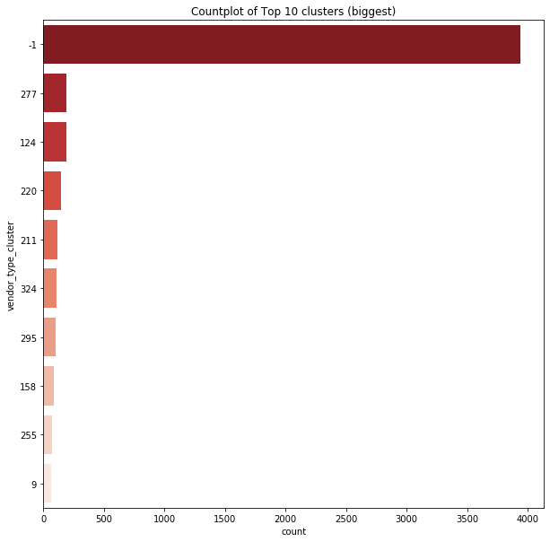

```python
plt.figure(figsize=(10, 10))
sns.countplot(y="vendor_type_cluster", data=df_menus_f, palette="Reds_r",
              order=df_menus_f.vendor_type_cluster.value_counts().iloc[:10].index)
plt.title("Countplot of Top 10 clusters (biggest)")
```

#### Let's Observer these Clusters

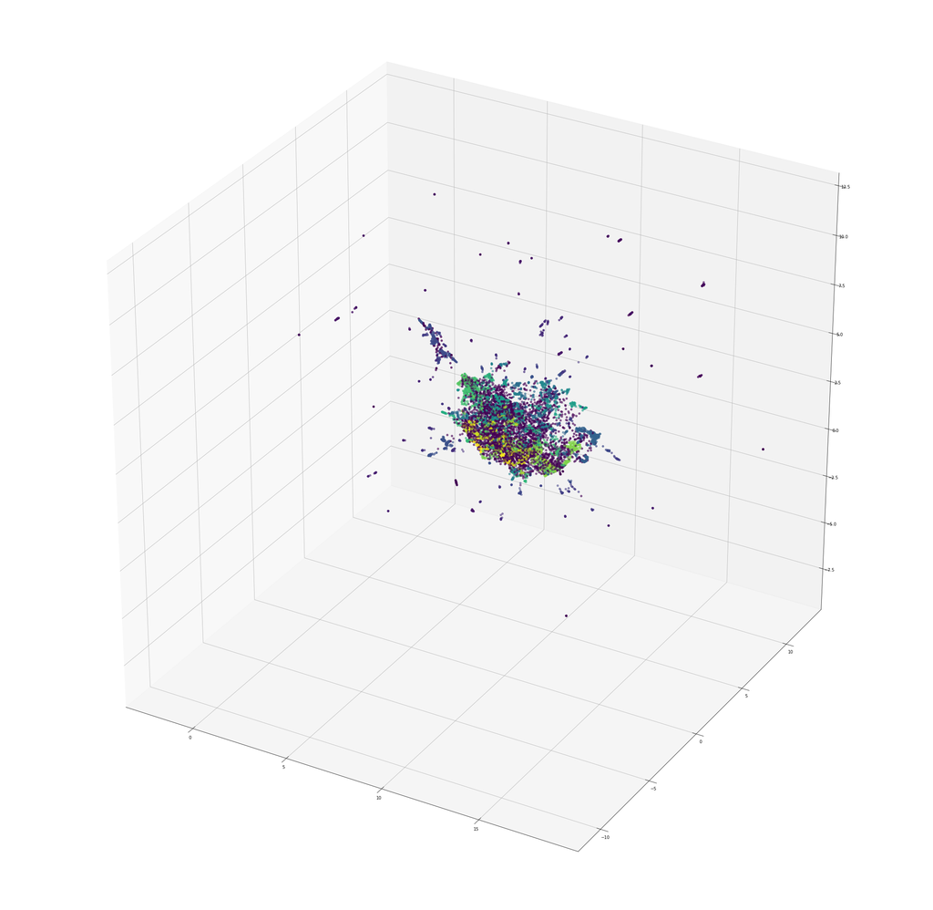

```python
fig = plt.figure(figsize=(40, 40))
ax = fig.add_subplot(111, projection='3d')
ax.scatter(*zip(*embedding[:,:3]), c=clusterer.labels_)
plt.show()
```

# Let's Join the cluster Id to the product table

Now have vendors joined into clusters. For a given user we can simply look at the top 10 products proposed by other vendors from same cluster :)

```python
df_en_f = df_en.merge(df_menus_f)
processor = EnglishTextProcessor()
```

```python
class NewItemsRecommender:
    def __init__(self, df_cluster, text_processor):
        """
        Init

        :param df_cluster: table with products and vendors clustered
        :param text_processor: the NLP text processor
        """
        self.df_cluster = df_cluster
        self.text_processor = text_processor

    def top10_products_to_consider(self, vendor_id: int, n_top_p: int):
        """
        Proposes the top 10 products to consider to add with buzz words/ingredients in the name/description

        :param vendor_id: the vendor_id
        :param n_top_p: the top N products to show from similar vendors
        """
        try:
            cluster_id = self.df_cluster.loc[self.df_cluster.vendor_id == vendor_id].iloc[0]["vendor_type_cluster"]

            products_similar_vendors = self.df_cluster.loc[
                (self.df_cluster.vendor_type_cluster == cluster_id) & (self.df_cluster.vendor_id != vendor_id)]

            products_similar_vendors = products_similar_vendors.sort_values("order_count", ascending=False).drop_duplicates(["vendor_id", "product_name"]).iloc[:n_top_p]

            output = []
            for el in products_similar_vendors.iterrows():
                row = el[-1]
                product_name_keywords = self.text_processor.preprocess_text(row["product_name"])
                description_name_keywords = self.text_processor.preprocess_text(row["product_description"])
                location = row["vendor_geohash"]
                output.append({
                    "product_name_keywords": product_name_keywords,
                    "description_name_keywords": description_name_keywords,
                    "recommended_location": location,
                })

            return output
        except Exception:
            raise
```

```python
recommender = NewItemsRecommender(df_en_f, processor)
```

```python
# list of recommended Products and suggestions for user 13297
recommender.top10_products_to_consider(13297, 10)
```

```
[{'product_name_keywords': ['chicken',
   'coney',
   'dog',
   'beef',
   'sauce',
   'combo'],
  'description_name_keywords': ['chicken',
   'coney',
   'dog',
   'beef',
   'sauce',
   'reg',
   'curly',
   'fry',
   'reg',
   'root',
   'beer',
   'beverage',
   'delivered',
   'takeaway',
   'cup'],
  'recommended_location': 'w21zwre'},
 {'product_name_keywords': ['pc', 'golden', 'chicken', 'combo'],
  'description_name_keywords': ['piece',
   'golden',
   'reg',
   'curly',
   'fry',
   'reg',
   'root',
   'beer',
   'chicken',
   'part',
   'served',
   'based',
   'availability',
   'beverage',
   'delivered',
   'takeaway',
   'cup'],
```

[output cut: 68 more lines]

```
   'takeaway',
   'cup'],
  'recommended_location': 'w21zwre'},
 {'product_name_keywords': ['chicken', 'coney', 'dog', 'beef', 'sauce'],
  'description_name_keywords': ['chicken',
   'hot',
   'dog',
   'topped',
   'signature',
   'coney',
   'beef',
   'sauce',
   'diced',
   'onion'],
  'recommended_location': 'w21zwre'}]
```

```python
# list of recommended Products and suggestions for user 7
recommender.top10_products_to_consider(7, 10)
```

```
[{'product_name_keywords': ['creamy', 'chicken'],
  'description_name_keywords': ['chicken', 'smooth', 'creamy', 'sauce'],
  'recommended_location': 'w21zun2'},
 {'product_name_keywords': ['build', 'pasta', 'coke'],
  'description_name_keywords': ['coke'],
  'recommended_location': 'w21zfc4'},
 {'product_name_keywords': ['cheddar', 'cheese', 'stick'],
  'description_name_keywords': ['coated',
   'golden',
   'bread',
   'crumb',
   'stuffed',
   'tasty',
   'cheddar',
   'cheese'],
  'recommended_location': 'w21zun2'},
 {'product_name_keywords': ['creamy', 'chicken'],
  'description_name_keywords': ['chicken', 'smooth', 'creamy', 'sauce'],
  'recommended_location': 'w23b4u6'},
 {'product_name_keywords': ['cheddar', 'cheese', 'stick'],
  'description_name_keywords': ['coated',
   'golden',
   'bread',
   'crumb',
   'stuffed',
   'tasty',
   'cheddar',
   'cheese'],
  'recommended_location': 'w21z8vu'},
 {'product_name_keywords': ['cheddar', 'cheese', 'stick'],
  'description_name_keywords': ['coated',
   'golden',
   'bread',
   'crumb',
   'stuffed',
   'tasty',
   'cheddar',
   'cheese'],
  'recommended_location': 'w23b4u6'},
 {'product_name_keywords': ['cheddar', 'cheese', 'stick'],
```

[output cut: 24 more lines]

```
   'tomato',
   'tossed',
   'olive',
   'oil'],
  'recommended_location': 'w23b4u6'},
 {'product_name_keywords': ['cheddar', 'cheese', 'stick'],
  'description_name_keywords': ['coated',
   'golden',
   'bread',
   'crumb',
   'stuffed',
   'tasty',
   'cheddar',
   'cheese'],
  'recommended_location': 'w23b4qt'}]
```

### Further improvement ideas

- **experiment with tf-idf + TruncatedSVD for data representation**
- **Add other features**: Add other features like price of product, type of meal "vegetarian"/"meat"/"dessert"